# Money Ball

## Load the data

`r`r library(Lahman)

`r`r str(Teams)

```
'data.frame':   2835 obs. of  53 variables:
 $ yearID        : int  1871 1871 1871 1871 1871 1871 1871 1871 1871 1872 ...
 $ lgID          : Factor w/ 7 levels \AA\,\AL\,\FL\,..: 4 4 4 4 4 4 4 4 4 4 ...
 $ teamID        : Factor w/ 149 levels \ALT\,\ANA\,\ARI\,..: 24 31 39 56 90 97 111 136 142 8 ...
 $ franchID      : Factor w/ 120 levels \ALT\,\ANA\,\ARI\,..: 13 36 25 56 70 85 91 109 77 9 ...
 $ divID         : chr  NA NA NA NA ...
 $ Rank          : int  3 2 8 7 5 1 9 6 4 2 ...
 $ G             : int  31 28 29 19 33 28 25 29 32 58 ...
 $ Ghome         : int  NA NA NA NA NA NA NA NA NA NA ...
 $ W             : int  20 19 10 7 16 21 4 13 15 35 ...
 $ L             : int  10 9 19 12 17 7 21 15 15 19 ...
 $ DivWin        : chr  NA NA NA NA ...
 $ WCWin         : chr  NA NA NA NA ...
 $ LgWin         : chr  \N\ \N\ \N\ \N\ ...
 $ WSWin         : chr  NA NA NA NA ...
```

[output cut: 39 more lines]

`r`r head(Teams)

|  | yearID | lgID | teamID | franchID | divID | Rank | G | Ghome | W | L | DivWin | WCWin | LgWin | WSWin | R | AB | H | X2B | X3B | HR | BB | SO | SB | CS | HBP | SF | RA | ER | ERA | … |
| --- | --- | --- | --- | --- | --- | --- | --- | --- | --- | --- | --- | --- | --- | --- | --- | --- | --- | --- | --- | --- | --- | --- | --- | --- | --- | --- | --- | --- | --- | --- |
| 1 | 1871 | NA | BS1 | BNA | NA | 3 | 31 | NA | 20 | 10 | NA | NA | N | NA | 401 | 1372 | 426 | 70 | 37 | 3 | 60 | 19 | 73 | NA | NA | NA | 303 | 109 | 3.55 | … |
| 2 | 1871 | NA | CH1 | CNA | NA | 2 | 28 | NA | 19 | 9 | NA | NA | N | NA | 302 | 1196 | 323 | 52 | 21 | 10 | 60 | 22 | 69 | NA | NA | NA | 241 | 77 | 2.76 | … |
| 3 | 1871 | NA | CL1 | CFC | NA | 8 | 29 | NA | 10 | 19 | NA | NA | N | NA | 249 | 1186 | 328 | 35 | 40 | 7 | 26 | 25 | 18 | NA | NA | NA | 341 | 116 | 4.11 | … |
| 4 | 1871 | NA | FW1 | KEK | NA | 7 | 19 | NA | 7 | 12 | NA | NA | N | NA | 137 | 746 | 178 | 19 | 8 | 2 | 33 | 9 | 16 | NA | NA | NA | 243 | 97 | 5.17 | … |
| 5 | 1871 | NA | NY2 | NNA | NA | 5 | 33 | NA | 16 | 17 | NA | NA | N | NA | 302 | 1404 | 403 | 43 | 21 | 1 | 33 | 15 | 46 | NA | NA | NA | 313 | 121 | 3.72 | … |
| 6 | 1871 | NA | PH1 | PNA | NA | 1 | 28 | NA | 21 | 7 | NA | NA | Y | NA | 376 | 1281 | 410 | 66 | 27 | 9 | 46 | 23 | 56 | NA | NA | NA | 266 | 137 | 4.95 | … |

## Data Analysis

`r`r library(dplyr) library(tidyr) library(ggplot2) library(dslabs)

Lets analyze a few variables against Runs per game -> Home runs per game -> Stolen Bases per game -> Base on Balls per game

Lets compute these variables

`r`r Teams <- Teams %>% mutate(R_per_game = R/G, HR_per_game = HR/G, SB_per_game = SB/G, BB_per_game = BB/G, AB_per_game = AB/G ) str(Teams)

[output not shown]

[output cut: 39 more lines]

`r`r ?Teams

#### Plot: home runs per game vs. runs per game

`r`r ds_theme_set() Teams %>% filter(yearID %in% 1961:2001) %>% ggplot(aes(HR_per_game, R_per_game)) + geom_point(alpha = 0.5) + # geom_abline() stat_smooth(method = ) # Adds a

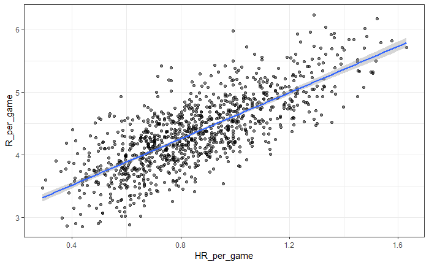

#### Plot: stolen bases per game vs. runs per game

`r`r Teams %>% filter(yearID %in% 1961:2001) %>% ggplot(aes(SB_per_game, R_per_game)) + geom_point(alpha = 0.5) + # geom_abline() stat_smooth(method = ) # Adds a

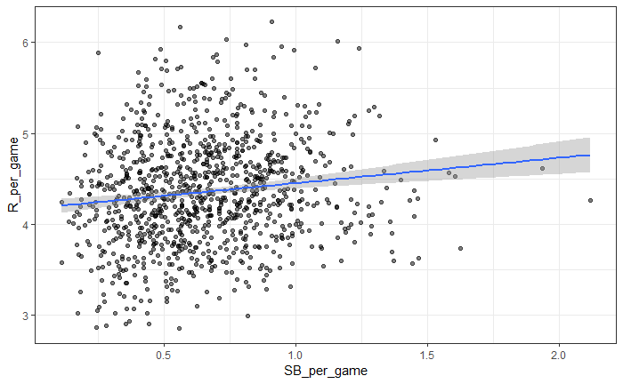

#### Plot: bases on ball per game vs. runs per game

`r`r Teams %>% filter(yearID %in% 1961:2001) %>% ggplot(aes(BB_per_game, R_per_game)) + geom_point(alpha = 0.5) + # geom_abline() stat_smooth(method = ) # Adds a

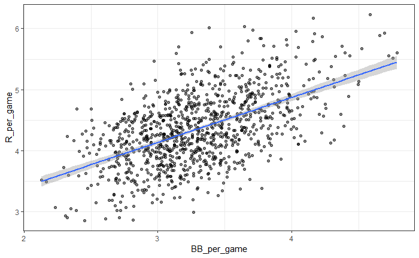

#### Plot: at-bats per game vs. runs per game

`r`r Teams %>% filter(yearID %in% 1961:2001) %>% ggplot(aes(AB_per_game, R_per_game)) + geom_point(alpha = 0.5) + # geom_abline() stat_smooth(method = ) # Adds a

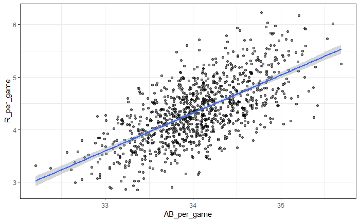